# Preliminary Analyses of the Colorado PhenX Substance Use Data

2017-01-31

```r
library(ggplot2)
library(readr)
library(dplyr)
library(broom)
library(forcats)
# The 'labelled' class columns need to be converted to standard data types
phenx <- read_rds('../data/raw/Robin_PhenX_12-6-16.rds')
phenx$id <- as.character(phenx$id)
ever_drinkers <- phenx %>% filter(PHXQ0001 == 1)
drinkers <- phenx %>% filter(PHXQ0002 == 1)
# Set non-drinkers who have had at least one drink to zero instead of missing
# on Days of Drinking (PHXQ0005) and on Drinks per Session (PHXQ0009)
phenx$PHXQ0005[is.na(phenx$PHXQ0005) & !is.na(phenx$PHXQ0003)] = 0
phenx$PHXQ0009[is.na(phenx$PHXQ0009) & !is.na(phenx$PHXQ0003)] = 0
twin_info <- read_rds('../data/raw/Robin_paper-entry_12-6-16.rds')
twin_info$ID1 <- as.character(twin_info$ID1)
twin_info$Test_AgeYears <- as.numeric(twin_info$Test_AgeYears)
twin_info$Test_AgeMonths <- as.numeric(twin_info$Test_AgeMonths)
twin_info$Test_AgeDays <- as.numeric(twin_info$Test_AgeDays)
# Calculate a single age variable
twin_info$Age <- twin_info$Test_AgeYears + (twin_info$Test_AgeMonths / 12) +
  (twin_info$Test_AgeDays / 365)
# Give sex more useful levels
twin_info$Sex1 <- fct_recode(as.factor(twin_info$Sex1),
                             'Male' = '1',
                             'Female' = '2')
# Join the data frames on SVID
joined <- left_join(phenx, twin_info, by = c('id' = 'ID1'))
# A function to format floats
comma <- function(x) format(x, digits = 2, nsmall = 2, big.mark = ",")
```

In the initial in-person COTWINS assessments, twins were asked standardized questions about substance use, derived from the [PhenX Toolkit](https://www.phenxtoolkit.org/index.php?pageLink=browse.conceptualgroups&id=3354&breadcrumbs=3354). The goal of this notebook is to do some preliminary descriptive analyses and QC on these data.

The age distribution of the twins is:

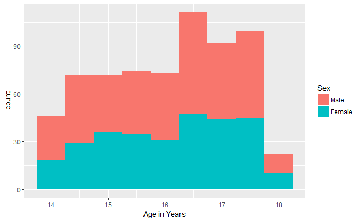

```r
joined %>%
  ggplot() +
  geom_histogram(aes(x = Age, fill = Sex1), binwidth = 0.5) +
  labs(fill = 'Sex', x = 'Age in Years')
```

Oddly, nine twins have missing values for their ages in months or days at test:

```r
twin_info %>%
  filter(is.na(Age)) %>%
  select(Test_Year:Test_AgeDays, Age) %>%
  knitr::kable()
```

| Test_Year | Test_Month | Test_Day | Birth_Year | Birth_Month | Birth_Day | Test_AgeYears | Test_AgeMonths | Test_AgeDays | Age |
| --- | --- | --- | --- | --- | --- | --- | --- | --- | --- |
| 2015 | 10 | 24 | 1999 | 9 | 29 | 16 | NaN | 25 | NaN |
| 2015 | 10 | 24 | 1999 | 9 | 29 | 16 | NaN | 25 | NaN |
| 16 | 1 | 4 | 0 | 12 | 28 | 15 | NaN | 6 | NaN |
| 2016 | 6 | 20 | 2001 | 5 | 22 | 15 | NaN | 28 | NaN |
| 2016 | 6 | 28 | 1998 | 11 | 25 | 17 | 7 | NaN | NaN |
| 2016 | 8 | 1 | 2000 | 1 | 1 | 16 | 7 | NaN | NaN |
| 2016 | 8 | 10 | 2000 | 5 | 10 | 16 | 3 | NaN | NaN |
| 2016 | 8 | 21 | 1999 | 8 | 19 | 17 | NaN | 2 | NaN |
| 2016 | 8 | 23 | 2000 | 8 | 23 | 16 | NaN | NaN | NaN |

# Alcohol

Out of 670 twins, 370 male and 300 female, 254 admit to having at least one drink of alcohol and 143 admit to having had more than five drinks of whom 140 and 77 are male, respectively. The mean age of drinking initiation was 14.88, with this distribution, which shows some obvious outliers:

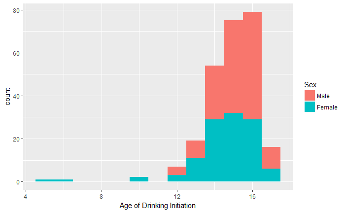

```r
joined %>%
  ggplot() +
  geom_histogram(aes(x = PHXQ0003, fill = Sex1), binwidth = 1) +
  labs(fill = 'Sex', x = 'Age of Drinking Initiation')
```

And the age at which participants began drinking once a month or more:

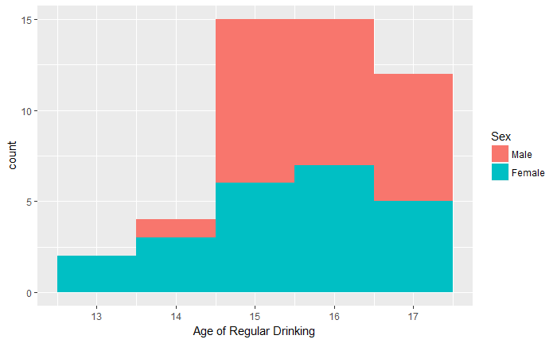

```r
joined %>%
  filter(PHXQ0004 != 0) %>%
  ggplot() +
  geom_histogram(aes(x = PHXQ0004, fill = Sex1), binwidth = 1) +
  labs(fill = 'Sex', x = 'Age of Regular Drinking')
```

We observe that the mean age of ever drinkers is 16.08 and that of never drinkers is 15.26. Summaries of other questions follow.

During the past 30 days, on how many days did you have one or more drinks?

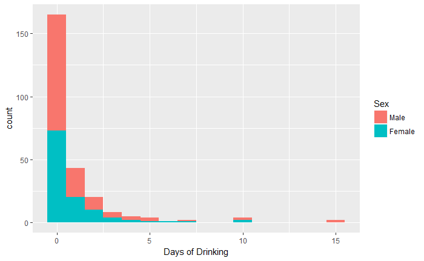

```r
joined %>%
  ggplot() +
  geom_histogram(aes(x = PHXQ0005, fill = Sex1), binwidth = 1) +
  labs(fill = 'Sex', x = 'Days of Drinking')
```

How does the number of days of drinking vary with age?

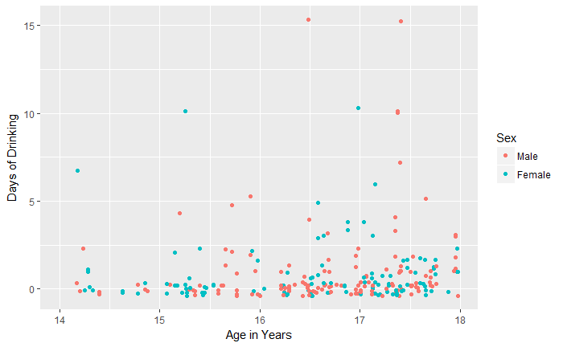

```r
joined %>%
  ggplot(aes(x = Age, y = PHXQ0005, color = Sex1)) +
  geom_jitter() +
  labs(color = 'Sex', x = 'Age in Years', y = 'Days of Drinking')
```

If we fit a linear model, we can see that age in years is not significantly correlated with days of drinking when we include drinkers who did not drink in the past month as zeroes.

```r
glance(lm(PHXQ0005 ~ Age, data = joined))
```

| r.squared | adj.r.squared | sigma | statistic | p.value | df | logLik | AIC | BIC | deviance | df.residual |
| --- | --- | --- | --- | --- | --- | --- | --- | --- | --- | --- |
| 0.00710622 | 0.003102616 | 2.131052 | 1.774956 | 0.1839929 | 2 | -542.8846 | 1091.769 | 1102.334 | 1126.263 | 248 |

During the past 30 days, when you drank, how many drinks did you have?

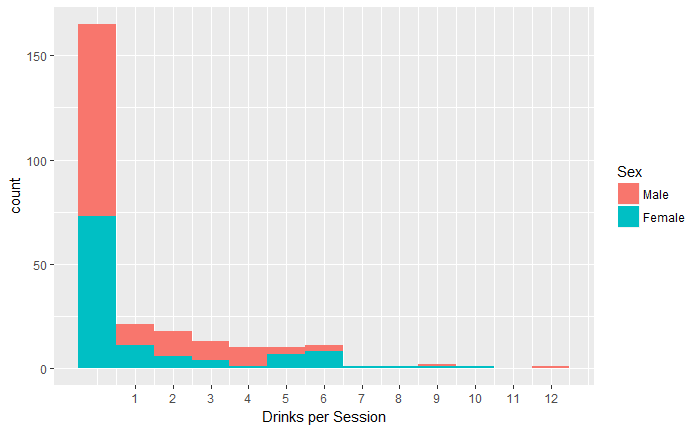

```r
joined %>%
  ggplot() + geom_histogram(aes(x = PHXQ0009, fill = Sex1), binwidth = 1) +
  labs(fill = 'Sex', x = 'Drinks per Session') +
  scale_x_continuous(breaks = seq(1, 12))
```

How does the number of drinks per session vary with age?

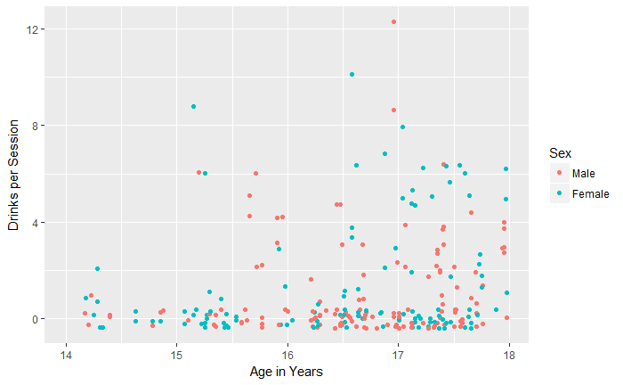

```r
joined %>%
  ggplot(aes(x = Age, y = PHXQ0009, color = Sex1)) +
  geom_jitter() +
  labs(color = 'Sex', x = 'Age in Years', y = 'Drinks per Session')
```

If we fit a linear model, we can see that age in years is significantly correlated with number of drinks per session if we include drinkers who did not drink in the past month as zeroes.

```r
glance(lm(PHXQ0009 ~ Age, data = joined))
```

| r.squared | adj.r.squared | sigma | statistic | p.value | df | logLik | AIC | BIC | deviance | df.residual |
| --- | --- | --- | --- | --- | --- | --- | --- | --- | --- | --- |
| 0.02922301 | 0.02530859 | 2.129065 | 7.465471 | 0.006741685 | 2 | -542.6513 | 1091.303 | 1101.867 | 1124.164 | 248 |

# Tobacco

3 twins have smoked at least 100 cigarettes.

# Marijuana

111 twins admit to having used marijuana. 68 twins admit to having used marijuana more than five times. The mean age of first use is 14.70. The mean age at which twins began using marijuana once a month or more is 15.02.

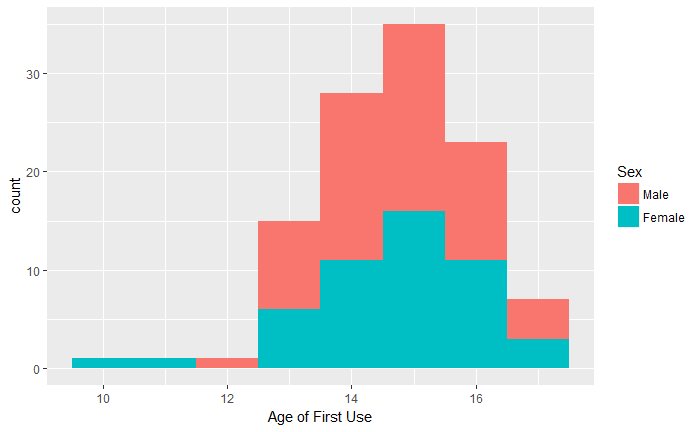

```r
joined %>%
  ggplot() +
  geom_histogram(aes(x = PHXQ0186, fill = Sex1), binwidth = 1) +
  labs(x = 'Age of First Use', fill = 'Sex')
```

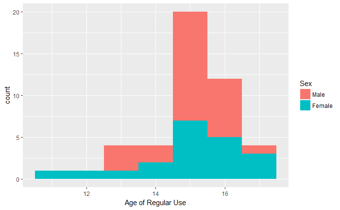

```r
joined %>%
  filter(PHXQ0187 != 0) %>%
  ggplot() +
  geom_histogram(aes(x = PHXQ0187, fill = Sex1), binwidth = 1) +
  labs(x = 'Age of Regular Use', fill = 'Sex')
```

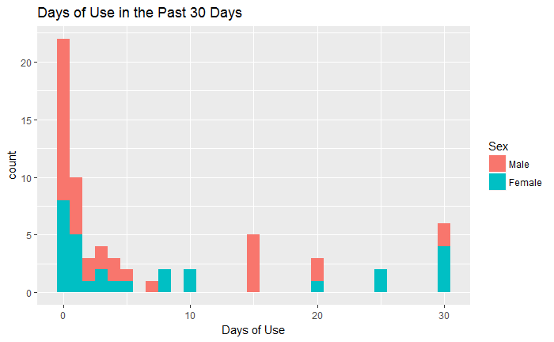

```r
joined %>%
  ggplot() +
  geom_histogram(aes(x = PHXQ0188, fill = Sex1), binwidth = 1) +
  labs(x = 'Days of Use', fill = 'Sex', title = 'Days of Use in the Past 30 Days')
```

Some sources of marijuana mentioned by participants:

```r
unique(joined$PHXQ0189_other)
```

```
 [1] ""
 [2] "dealer"
 [3] "friends who have red cards"
 [4] "step-sister, who got it from a friend, whose sister works at an apothacary"
 [5] "friend"
 [6] "at a party"
 [7] "friend who gets it from a legal retailer"
 [8] "Freind"
 [9] "friend/dealer who got it form a legal dispensary"
[10] "bought from a friend"
[11] "drug dealer"
[12] "Friend"
[13] "friends"
[14] "someone's dealer"
[15] "Friends"
[16] "Friend has med card"
[17] "from friend"
[18] "Streets"
[19] "family members"
[20] "friends - not from dispensary"
[21] "From a friend"
[22] "From friends"
[23] "Through friends"
[24] "dealer, they got it from retail location"
[25] "older friend"
[26] "friend who has med card, other friend gets it from a dealer"
[27] "friends that had their med cards"
[28] "friend got it from a dispensary"
[29] "older friend who got it from a legal dispensary"
```